# Model details

It’s academic team

s.contractor@unsw.edu.au

06 November, 2023

This document complements information presented in the dashboard. It contains technical information about the statistical modelling including the purposes of the model, associated statistical methodology and additional model results and validation diagnostics. Specifically, visualization and diagnostics associated with the predictive performances of the spatial Bayesian models. A leave-out data analysis is performed to assess model predictions with the exclusion of 20% of data randomly for each city using five prediction-performance measures.

### Spatial model

The spatial statistical model is developed to predict temperature anomalies (relative to 1981-2000 mean temperatures) across 5x5 km gridded locations within city bounding boxes. The model uses spatial random effects that are based on an automatic specification of spatial basis functions as well as fixed effects including greenness index, human population density and urban area. The model is fitted under an hybrid Bayesian and Frequentist framework using the R package FRK version 2.1.5 (Sainsbury-Dale, Zammit-Mangion, and Cressie 2021) and a normal probability distribution. Statistical and computational details can be found in the two main FRK papers (Zammit-Mangion and Cressie 2021; Sainsbury-Dale, Zammit-Mangion, and Cressie 2021). Model codes are available at https://github.com/UN-Datathon-Its-Academic for reproducibility.

### Fixed effects

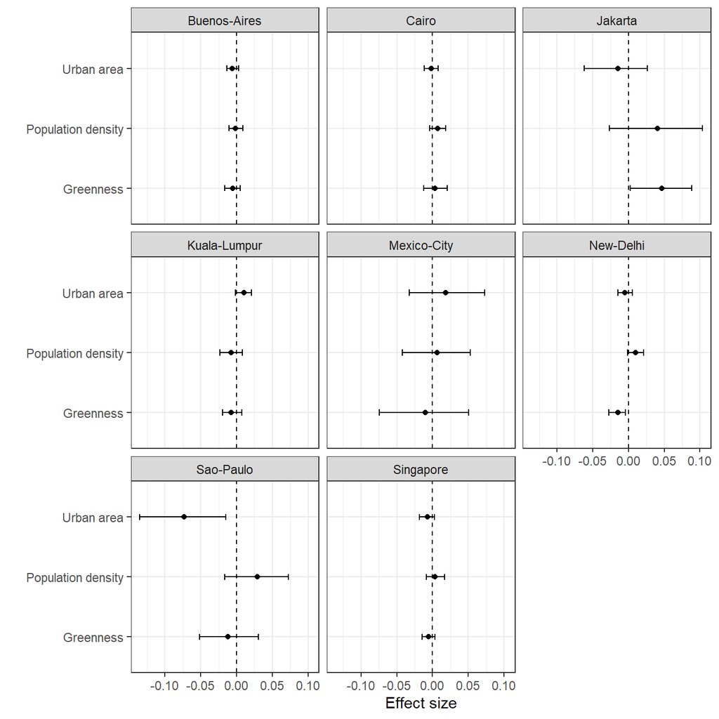

Figure 1: Effect size of the model covariates for each city. Dots shows averaged size effect and error bars corresponding to the 95% credible intervals.

### Model predictive capability

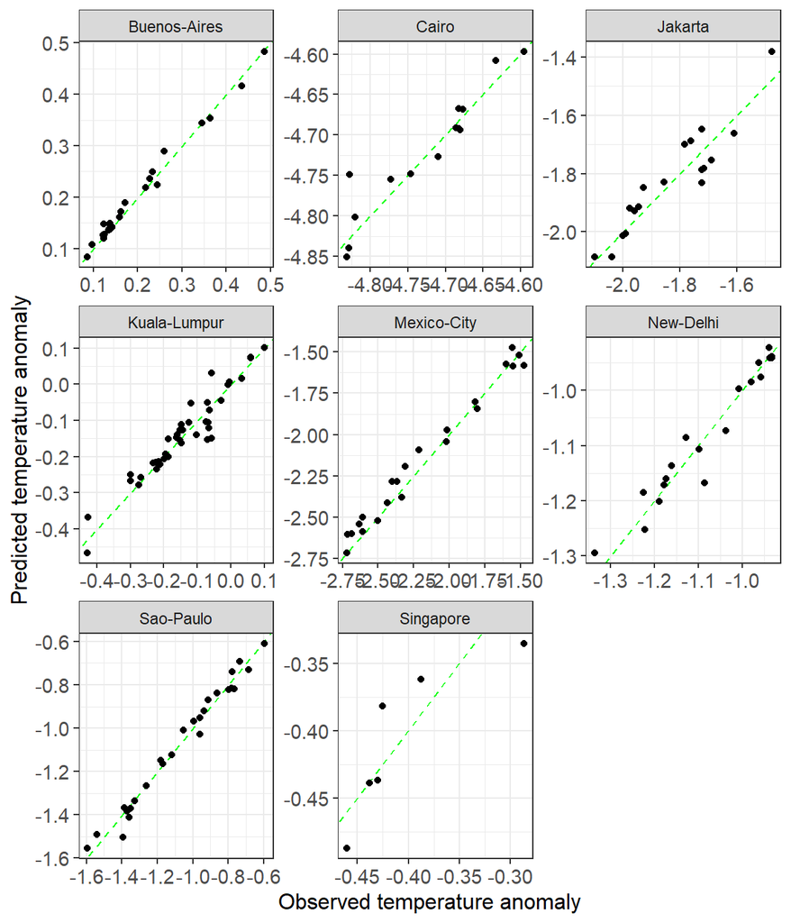

Figure 2: Predicted temperature anomalies (y axis) relative to true temperature anomalies (x axis).

With the exception of Singapore which had only 23 data points to train on, our predictions lie very close to the 1-1 line.

### Model diagnostics

Table 1: Measures of performance for model forecasts

| City | 95% coverage | 95% interval score | Root-mean-squared prediction error | Continuous ranked probability score | AIC |
| --- | --- | --- | --- | --- | --- |
| Buenos-Aires | 0.92 | 0.06 | 0.01 | 0.01 | -436.99 |
| Cairo | 0.93 | 0.14 | 0.03 | 0.02 | -222.51 |
| Jakarta | 1 | 0.29 | 0.06 | 0.07 | -95.2 |
| Kuala-Lumpur | 0.83 | 0.17 | 0.03 | 0.02 | -602.72 |
| Mexico-City | 0.77 | 0.27 | 0.07 | 0.06 | -143.42 |
| New-Delhi | 0.67 | 0.18 | 0.03 | 0.02 | -329.7 |
| Sao-Paulo | 0.96 | 0.17 | 0.04 | 0.04 | -226.75 |
| Singapore | 0.33 | 0.25 | 0.03 | 0.02 | -86.81 |

Sainsbury-Dale, Matthew, Andrew Zammit-Mangion, and Noel Cressie. 2021. “Modelling Big, Heterogeneous, Non-Gaussian Spatial and Spatio-Temporal Data Using FRK.” *arXiv Preprint arXiv:2110.02507*.

Zammit-Mangion, Andrew, and Noel Cressie. 2021. “FRK: An r Package for Spatial and Spatio-Temporal Prediction with Large Datasets.” *Journal of Statistical Software* 98 (4). https://doi.org/10.18637/jss.v098.i04.